# Exploring the BRFSS data

**Dataset:** BRFSS  
**Source:** https://www.cdc.gov/brfss/  
**Summary:** The data set is a collection of ~400,000 adult interviews across the United States on health related topics. The data is a combination of self-reported answers and reported biometrics. The features are continuous, ordinal, and discrete. Some features have missing values so data preprocessing is essential. Because the participants were selected randomly the sample can be generalized. This data is not from experimental research so while correlation can be inferred causality can not be inferred.  
**Goals:** Explore any correlations among gender, weight, and weight

## Part 0: Setup

#### Load packages

```r
library(ggplot2)
library(dplyr)
library(Rgraphviz)
library(knitr)
library(grid)
```

#### Load data

Load the file:

```r
load("brfss2013.RData")
```

Functions for analysis:

```r
feature_vcounts <- function(df, f) {
  df %>%
    group_by_at(f) %>%
      count()
}

bin_min_sample <- function(p) {
  n = 10
  a = 10/p
  b = 10/(1-p)
  max(c(a,b))
}

binom_prob_df <- function(df, f, target) {
  new_df <- feature_vcounts(df,f)
  new_df$n[new_df[f] == target]/sum(new_df$n)
}

subgroup_df <- function(df,f, group) {
  filter(df,df[f]==group)
}

binom_prob_vec <- function(v, target) {
  sum(v == target)/length(v)
}

binom_sample <- function(s,v)
  sample(v, size=s, replace=TRUE)

binom_sample_dist <- function(df,f,target) {
  sample_dist <- c()
  for (i in 1:10001) {
    prob <- binom_prob_vec(binom_sample(100,df[,f]),target)
    sample_dist <- append(sample_dist,prob)
  }
  return(sample_dist)
}

to_percent <- function(pvalue) {
  paste(round(pvalue*100,digits= 2),"%",sep="")
}
```

## Part 1: Data

Import and filter the data to only include important features. Reduce features to 3 and then clean the data.

```r
# Import original file:
orig_dim <- dim(brfss2013)

# Select only relevant features:
weight_diabetes <- brfss2013 %>%
   select(sex, weight2,diabete3)

# Clean data:
# 1.Weight strings -> numeric
weight_diabetes$weight2 <- as.numeric(as.character(weight_diabetes$weight2))
new_dim <- dim(weight_diabetes)

# 2. Remove Null Weights and Weights over 400
weight_diabetes <- na.omit(weight_diabetes)
weight_diabetes <- filter(weight_diabetes, weight2 <= 400)

# 3. Remove Diabetes Responses
target <- c("Yes", "No")
weight_diabetes <- filter(weight_diabetes, diabete3 %in% target)

# 4. Add index and reorder
weight_diabetes$index <- seq.int(nrow(weight_diabetes))
weight_diabetes <- weight_diabetes[c(4,3,1,2)]
clean_dim <- dim(weight_diabetes)

# Show data:
kable(head(weight_diabetes,n=5), caption="Diabetes Data Set",padding=0, format = "markdown",align="l")
```

| index | diabete3 | sex | weight2 |
| --- | --- | --- | --- |
| 1 | No | Female | 250 |
| 2 | No | Female | 127 |
| 3 | No | Female | 160 |
| 4 | No | Female | 128 |
| 5 | No | Male | 265 |

**Original dimensions:**  
[491775] x [330]  
**Reduced dimensions:**  
[491775] x [3]  
**After cleaning:**  
[456649] x [4]

* * *

## Part 2: Research questions

### **Research quesion 1:**

Because gender is a key variable in biometrics, it is important to explore whether gender might correllate to other variables. In this case, we are looking at whether or not sex correllates to weight.

### **Research question 2:**

#### What is the probability that a participant is heavy (weight > 200)?

I chose this metric for heavy arbitrarily, but I would like to know more about the probaility of a US citizen weighing more than 200 lbs. It is a stereotype that US citizens are obese/overweight and I would like to have a better understanding of the weight distribution for adults in the US.

### **Research question 3:**

#### What is the probability that a participant reports having diabetes given that they are male?

Because I’m male, I would like to know the basic probability that I would have diabetes given that I am male.

## Part 3: Exploratory data analysis

### **Research question 1:**

##### Weight2: (Continuous)

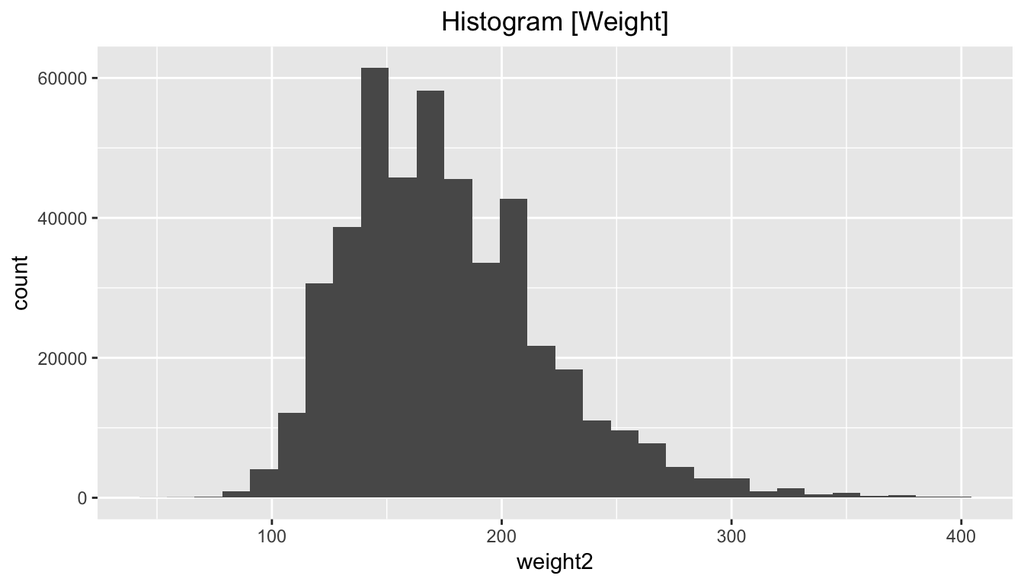

```r
centered <- theme(plot.title = element_text(hjust = 0.5))
hist_weight <-ggplot(data=weight_diabetes,aes(weight2))+
  geom_histogram()
hist_weight + ggtitle("Histogram [Weight]") + centered
```

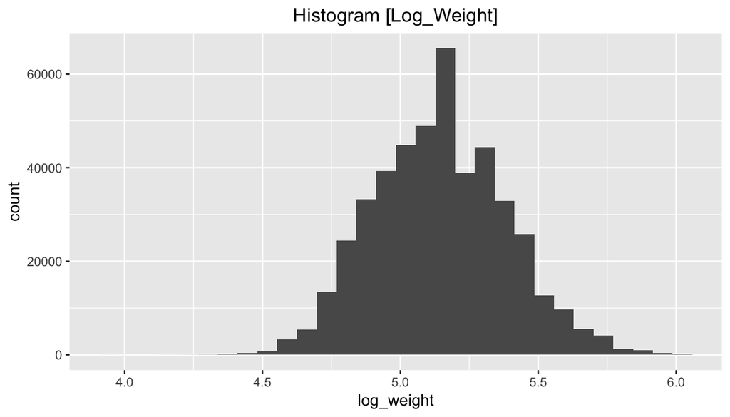

```r
weight_diabetes$log_weight <- log(weight_diabetes$weight2)
hist_log_weight <- ggplot(data=weight_diabetes,aes(log_weight))+
  geom_histogram()
hist_log_weight + ggtitle("Histogram [Log_Weight]") + centered
```

```r
head(weight_diabetes$log_weight, n=10)
```

```
##  [1] 5.521461 4.844187 5.075174 4.852030 5.579730 5.416100 4.663439
##  [8] 5.459586 5.135798 5.416100
```

```r
head(weight_diabetes$weight2,n=10)
```

```
##  [1] 250 127 160 128 265 225 106 235 170 225
```

For ‘Weight2’, the distribution is right skewed while the log of Weight 2 appears to be nearly normal.

##### Sex: (Discrete-Binary)

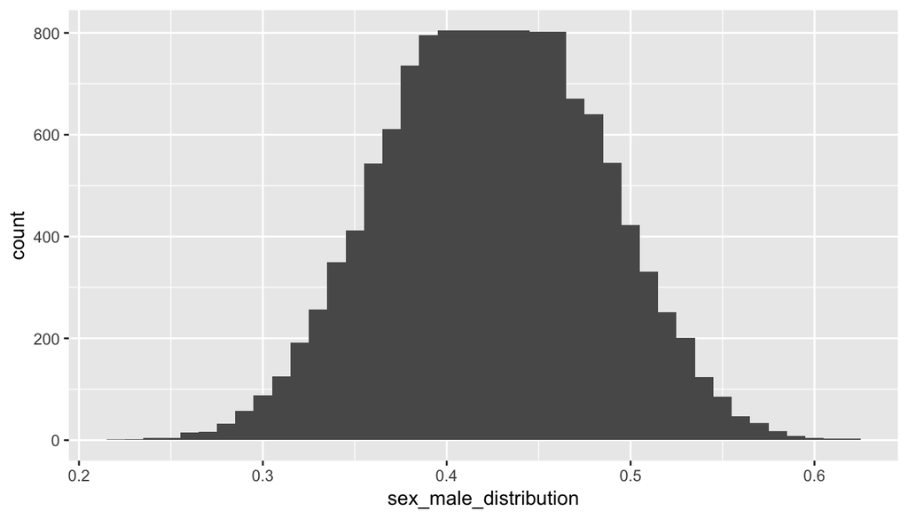

```r
sex_male_distribution <- binom_sample_dist(weight_diabetes,"sex","Male")

ggplot()+
  aes(x=sex_male_distribution)+
  geom_bar(width = 0.05)
```

```r
gp_male <- binom_prob_vec(weight_diabetes$sex,"Male")
```

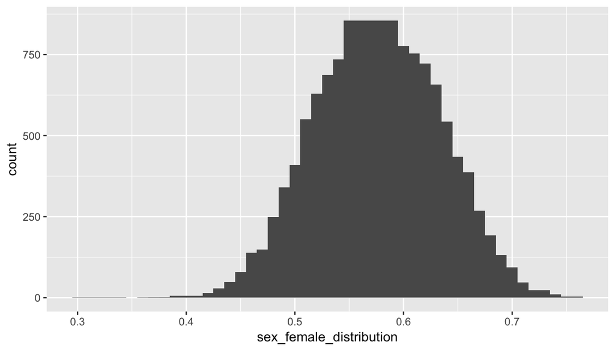

```r
sex_female_distribution <- binom_sample_dist(weight_diabetes,"sex","Female")

ggplot()+
  aes(x=sex_female_distribution)+
  geom_bar(width = 0.05)
```

```r
gp_female <- binom_prob_vec(weight_diabetes$sex,"Female")
```

##### Diabete3: (Discrete-Binary)

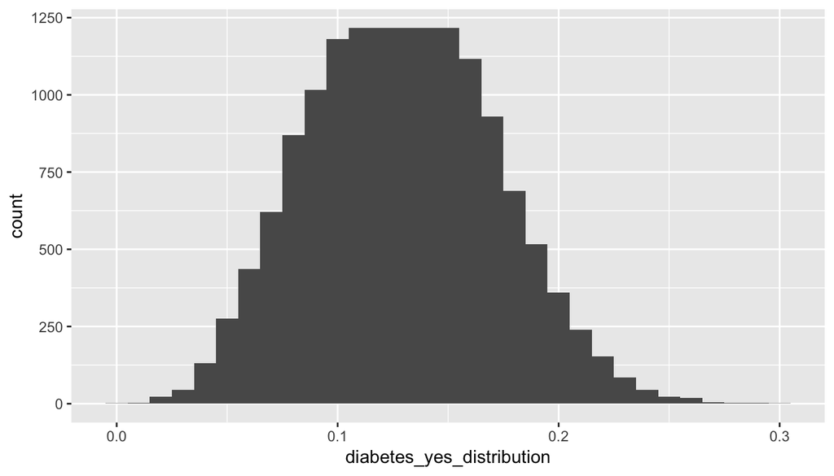

```r
diabetes_yes_distribution <- binom_sample_dist(weight_diabetes,"diabete3","Yes")

ggplot()+
  aes(x=diabetes_yes_distribution)+
  geom_bar(width = 0.05)
```

```r
dp_yes <- binom_prob_vec(weight_diabetes$diabete3,"Yes")
```

For ‘Diabete3’, the probability of the participant reporting diabetes is low at around **12.98%**

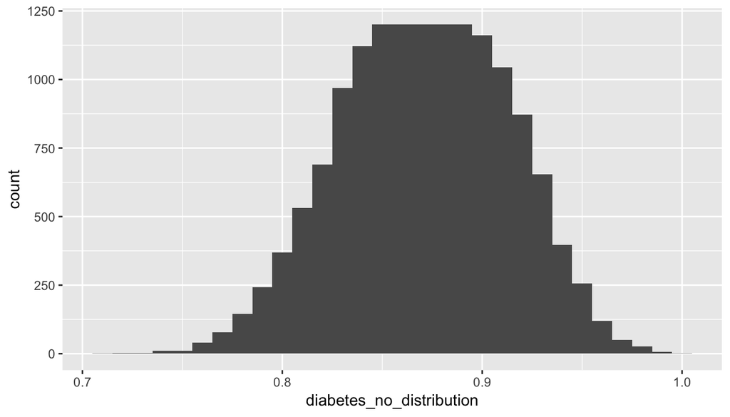

```r
diabetes_no_distribution <- binom_sample_dist(weight_diabetes,"diabete3","No")

ggplot()+
  aes(x=diabetes_no_distribution)+
  geom_bar(width = 0.05)
```

```r
dp_no <- binom_prob_vec(weight_diabetes$diabete3,"No")
```

For ‘Diabete3’, the probability of the participant reporting that they do not have diabetes is high at around **87.02%**

### **Research question 2:**

```r
# probability that participant is 200 lbs or more using right tailed distribution
sd_weight <- sd(weight_diabetes$weight2)
mean_weight <- mean(weight_diabetes$weight2)
z <- (200-mean_weight)/sd_weight
righttailed <-1-pnorm(z)

# probability that participant is 200 lbs or more using lognormed distribution
sd_weight <- sd(weight_diabetes$log_weight)
mean_weight <- mean(weight_diabetes$log_weight)
z <- (log(200)-mean_weight)/sd_weight
1-pnorm(z)
```

```
## [1] 0.2585847
```

```r
# probability that participant is 200 lbs or more
pvalue=1-exp(pnorm(log(200),mean_weight,sd_weight, log=TRUE))
pvalue
```

```
## [1] 0.2585847
```

```r
# percentage of heavy vs not heavy
weight_diabetes$heavy <- ifelse(weight_diabetes$weight2 < 200,"not_heavy","heavy")
actual <- binom_prob_vec(weight_diabetes$heavy,"heavy")
```

#### The probability that a participant is heavy is based on lognormed z-score is **25.86%**. The right-tailed z-score estimate is **29.34%**. The actual percentage is **27.47%**

### **Research question 3:**

```r
#gp_male
#gp_female

#dp_no
#dp_yes

male_diabetes_prob <- binom_prob_vec(subgroup_df(weight_diabetes,'sex','Male')$diabete3,"Yes")
female_diabetes_prob <- binom_prob_vec(subgroup_df(weight_diabetes,'sex','Female')$diabete3,"Yes")
#female_diabetes_prob
#male_diabetes_prob
```

```r
to_percent(gp_male * dp_yes)
```

```
## [1] "5.51%"
```

#### *Here is a tree diagram to help show the probability distribution*

**NOTE:** This part is built from a boilerplate template. It is another method for confirming the probability and exploring the data visually.

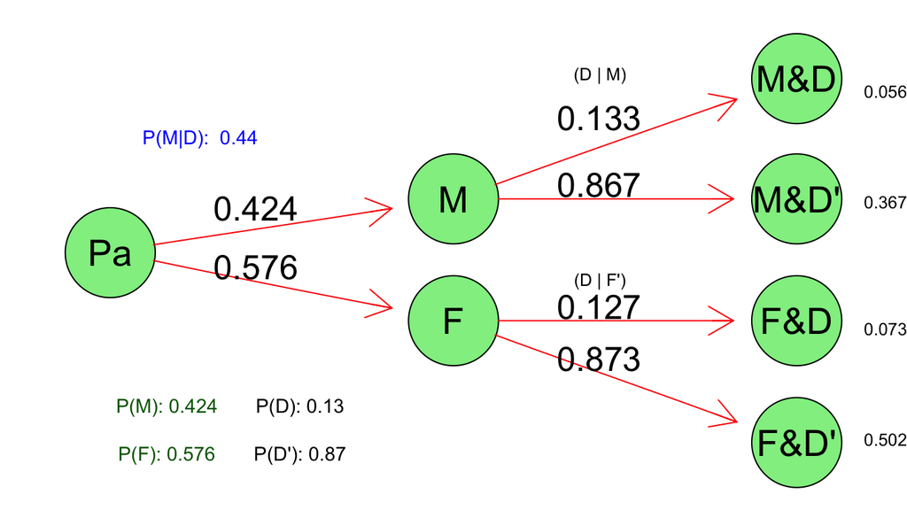

```r
# Tutorial by: http://www.harrysurden.com/wordpress/archives/292
# R Conditional Probability Tree Diagram

# The Rgraphviz graphing package must be installed to do this
require("Rgraphviz")

# Assign probabilities
a<-round(gp_male,digits= 3)
bGivena<-round(male_diabetes_prob,digits= 3)
bGivenNota<-round(female_diabetes_prob,digits= 3)

# Calculations
notbGivena<-1-bGivena
notA<-1-a
notbGivenNota<-1-bGivenNota
aANDb<-a*bGivena
aANDnotb<-a*notbGivena
notaANDb <- notA*bGivenNota
notaANDnotb <- notA*notbGivenNota
b<- aANDb + notaANDb
notB <- 1-b
aGivenb <- aANDb / b

# Text notation
node1<-"Pa"
node2<-"M"
node3<-"F"
node4<-"M&D"
node5<-"M&D'"
node6<-"F&D"
node7<-"F&D'"
nodeNames<-c(node1,node2,node3,node4, node5,node6, node7)
rEG <- new("graphNEL", nodes=nodeNames, edgemode="directed")

# Draw the "lines" or "branches" of the probability Tree
rEG <- addEdge(nodeNames[1], nodeNames[2], rEG, 1)
rEG <- addEdge(nodeNames[1], nodeNames[3], rEG, 1)
rEG <- addEdge(nodeNames[2], nodeNames[4], rEG, 1)
rEG <- addEdge(nodeNames[2], nodeNames[5], rEG, 1)
rEG <- addEdge(nodeNames[3], nodeNames[6], rEG, 1)
rEG <- addEdge(nodeNames[3], nodeNames[7], rEG, 10)

eAttrs <- list()
q<-edgeNames(rEG)

# Add the probability values to the the branch lines
eAttrs$label <- c(toString(a),toString(notA),
 toString(bGivena), toString(notbGivena),
 toString(bGivenNota), toString(notbGivenNota))
names(eAttrs$label) <- c(q[1],q[2], q[3], q[4], q[5], q[6])
edgeAttrs<-eAttrs

# Set the color, etc, of the tree
attributes<-list(node=list(label="foo", fillcolor="lightgreen", fontsize="15"),
 edge=list(color="red"),graph=list(rankdir="LR"))

#Plot the probability tree using Rgraphvis
plot(rEG, edgeAttrs=eAttrs, attrs=attributes)
#nodes(rEG)
#edges(rEG)

#Add the probability values to the leaves of A&B, A&B', A'&B, A'&B'
text(520,250,aANDb, cex=.8)
text(520,180,aANDnotb,cex=.8)
text(520,100,notaANDb,cex=.8)
text(520,30,notaANDnotb,cex=.8)
text(340,260,"(D | M)",cex=.8)
text(340,130,"(D | F')",cex=.8)

#Write a table in the lower left of the probablites of A and B
text(80,50,paste("P(M):",a),cex=.9, col="darkgreen")
text(80,20,paste("P(F):",notA),cex=.9, col="darkgreen")
text(160,50,paste("P(D):",round(b,digits=2)),cex=.9)
text(160,20,paste("P(D'):",round(notB, 2)),cex=.9)
text(100,220,paste("P(M|D): ",round(aGivenb,digits=2)),cex=.9,col="blue")
```

## Part 4: Conclusion

I have a better understanding of both the weight distribution of adults in the US and of the probability that I have diabetes given that I am male. I still have a lot that I need to do with regards to this data set as I have barely scratched the surface. My next step would be to check and see how weight influences the probability that I have diabetes (i.e. What is the probability that I have diabetes given that I am both male and under 200lbs). I would also like to explore other features (e.g.age) to see how these other features might relate to diabetes.